# BST270_final

Arpan Sarkar

1/23/2021

# Overview

In this project, I aim to reproduce the COVID-19 visualizations and tables published by the New York Times. Specifically, I attempt to reproduce the following for January 17th, 2021:

1. New cases as a function of time with a rolling average plot
2. Table of cases, hospitalizations and deaths
3. Table of cases by state

# Load relevant packages

```r
library(ggplot2)
library(tidyverse)
library(stringr)
library(zoo)
library(lubridate)
library(kableExtra)
```

# Data

Data for cases and deaths can be downloaded from this NYT GitHub repository (see us-counties.csv and us.csv). Data for hospitalizations can be downloaded from The COVID Tracking Project (see all-states-history.csv).

```r
states <- read.csv("Data/all-states-history.csv")
us <- read.csv("Data/us.csv")
us_s <- read.csv("Data/us-states.csv")
```

# Figure 1: New cases as a function of time with a rolling average plot

This figure features a graph of new Covid-19 cases per day with a rolling 7-day average plot of new Covid-19 cases.

As presented in the us.csv data, cases are cumulative, so it is necessary to create a new column with values for new cases for each recorded day.

```r
us$new_cases <- us$cases - lag(us$cases)
us$new_cases_7dayavg = rollmean(us$new_cases, k = 7, fill = NA,align="right")
```

In order to recreate the x-axis of the NYT figure more faithfully, I format the date column by month.

```r
us$date <- ymd(us$date)
us$month <- format(us$date,"%B")
```

The plot itself is created as follows:

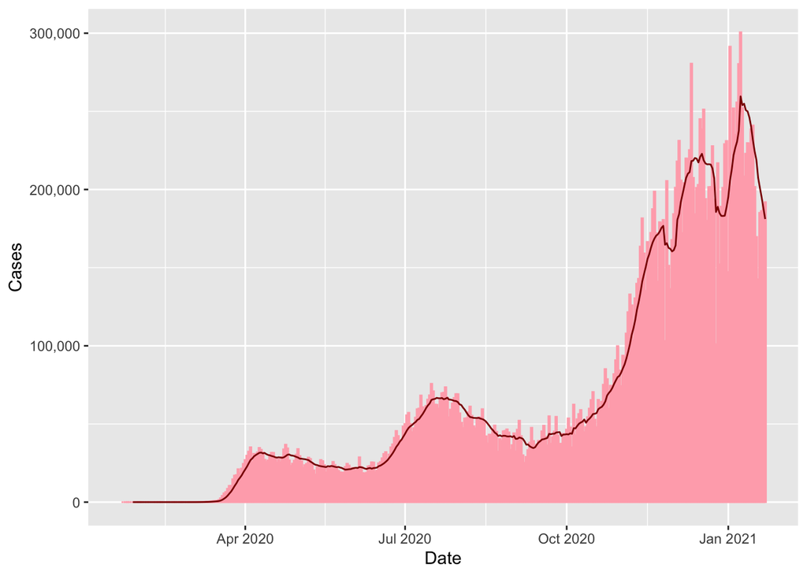

```r
plot <- ggplot(us, aes(date, new_cases)) + geom_col(aes(date, new_cases),color="lightpink1",alpha=0.8) +
  geom_path(aes(date,new_cases_7dayavg),color="darkred") +
  scale_y_continuous(breaks = c(0, 100000, 200000, 300000), labels = c("0", "100,000", "200,000", "300,000"))+
  xlab("Date")+
  ylab("Cases")
print(plot)
```

**Notes on Reproducibility:** This honestly seemed pretty clear from the figure provided in the problem specifications. It was clear that we were using new cases and the 7-day averages were fairly clear.

# Figure 2: Table of cases, hospitalizations and deaths

This figure features a table with total reported Covid-19 cases, total reported Covid-19 deaths, new recorded Covid-19 cases on Jan. 17th, new recorded Covid-19 deaths on Jan. 17th, Covid-19 hospitalizations on Jan. 17th, 14-day change for Covid-19 cases, 14-day change for Covid-19 deaths, and 14-day change for Covid-19 hospitalizations.

The total reported Covid-19 cases and Covid-19 deaths as of Jan. 17th are present in the original (un-modified) us.csv data set, and the number of current hospitalizations as of Jan. 17th is present in the original all-states-history.csv dataset. The new recorded Covid-19 cases on Jan. 17th was calculated in the process of generating Figure 1. The new recorded Covid-19 deaths on Jan. 17th can be calculated in a similar process:

```r
us$new_deaths  <- us$deaths - lag(us$deaths)
us$new_deaths_7dayavg = rollmean(us$new_deaths, k = 7, fill = NA, align="right")
```

In order to determine the 14-day changes (in percent), the values new cases, deaths, and current hospitalizations must be recorded for Jan. 3rd and Jan 17th. (14 days prior).

```r
Jan3_cd <- us[us$date == "2021-01-03",]
Jan17_cd <- us[us$date == "2021-01-17",]
```

The current hospitalizations should be grouped by date since otherwise the values provided are for each individual state/territory on any given day.

```r
total_hospitalizedCurrently = states %>%
  group_by(date) %>%
  summarize(totalnew_hosps = sum(hospitalizedCurrently, na.rm=T))
total_hospitalizedCurrently$date <- rev(unique(states$date))
```

Calculations of 14-day percent changes of new cases, deaths, and current hospitalizations. It is important to note that this uses 7-day averages for the calculations.

```r
total_hospitalizedCurrently$totalnew_hosps_7dayavg <- rollmean(total_hospitalizedCurrently$totalnew_hosps, k = 7, fill = NA, align = "right")
Jan3_hosp <- total_hospitalizedCurrently[total_hospitalizedCurrently$date == "2021-01-03",]
Jan17_hosp <- total_hospitalizedCurrently[total_hospitalizedCurrently$date == "2021-01-17",]
```

```r
cases_change <- (Jan17_cd$new_cases_7dayavg - Jan3_cd$new_cases_7dayavg)/Jan3_cd$new_cases_7dayavg * 100
deaths_change <- (Jan17_cd$new_deaths_7dayavg - Jan3_cd$new_deaths_7dayavg)/Jan3_cd$new_deaths_7dayavg * 100
hosp_change <- (Jan17_hosp$totalnew_hosps_7dayavg - Jan3_hosp$totalnew_hosps_7dayavg)/Jan3_hosp$totalnew_hosps_7dayavg * 100
```

Completing the table:

```r
Cases <- round(c(Jan17_cd$cases,Jan17_cd$new_cases, cases_change),digits=0)
Deaths <- round(c(Jan17_cd$deaths, Jan17_cd$new_deaths, deaths_change),digits=0)
Hospitalized <- c("",round(Jan17_hosp$totalnew_hosps,digits=0),round(hosp_change,digits=0))
table <- as.matrix(rbind(Cases, Deaths, Hospitalized))
colnames(table) <- c("TOTAL REPORTED","ON JAN 17", "14-DAY CHANGE")
kable(table,digits=2)
```

|  | TOTAL REPORTED | ON JAN 17 | 14-DAY CHANGE |
| --- | --- | --- | --- |
| Cases | 23983607 | 169641 | 3 |
| Deaths | 397612 | 1730 | 26 |
| Hospitalized |  | 124387 | 3 |

**Notes on Reproducibility:** This also seemed pretty clear from the figure provided in the problem specifications. It was not immediately obvious to me that there was a gray caption under the table that details that the 14-day changes uses 7-day averages.

# Figure 3: Table of cases by state

This figure features a table with the total Covid-19 cases and daily average in the last 7 days of Covid-19 cases grouped by state.

It is necessary to compute the new cases for each state (we already did this for us.csv, but it did not have the state labels).

```r
us_s <- us_s %>%
  group_by(state) %>%
  arrange(date) %>%
  mutate(new_cases = cases - lag(cases))
```

Again, the rolling 7-day averages should be computed.

```r
us_s <- us_s %>%
  group_by(state) %>%
  mutate(new_cases_7dayavg = rollmean(new_cases, k = 7, fill = NA, align = "right"))
```

Only select the data for Jan. 17th.

```r
Jan17_3 <- us_s[us_s$date=="2021-01-17",c("state","cases","new_cases_7dayavg")]
names(Jan17_3) <- c("State","Total Cases", "Daily Avg in Last 7 Days")
Jan17_3$`Daily Avg in Last 7 Days` <- round(Jan17_3$`Daily Avg in Last 7 Days`)
```

Completing the table:

```r
options(scipen=999)
kable(Jan17_3)
```

| State | Total Cases | Daily Avg in Last 7 Days |
| --- | --- | --- |
| Alabama | 422598 | 2957 |
| Alaska | 51630 | 242 |
| Arizona | 673882 | 7905 |
| Arkansas | 271154 | 2297 |
| California | 3006583 | 39580 |
| Colorado | 376921 | 1986 |
| Connecticut | 223422 | 2490 |
| Delaware | 70294 | 717 |
| District of Columbia | 33851 | 294 |
| Florida | 1571271 | 13467 |
| Georgia | 791322 | 8457 |
| Guam | 8453 | 10 |
| Hawaii | 24309 | 144 |
| Idaho | 155617 | 839 |
| Illinois | 1071307 | 5717 |
| Indiana | 593262 | 3799 |
| Iowa | 305151 | 1210 |
| Kansas | 259226 | 1957 |
| Kentucky | 329816 | 3285 |
| Louisiana | 368980 | 3164 |
| Maine | 33559 | 609 |
| Maryland | 326648 | 2828 |
| Massachusetts | 470140 | 5336 |
| Michigan | 580394 | 2846 |
| Minnesota | 446448 | 1401 |
| Mississippi | 252475 | 1913 |
| Missouri | 468106 | 2460 |
| Montana | 89393 | 438 |
| Nebraska | 182139 | 848 |
| Nevada | 261847 | 1870 |
| New Hampshire | 56864 | 752 |
| New Jersey | 627221 | 6056 |
| New Mexico | 163637 | 1069 |
| New York | 1242818 | 15281 |
| North Carolina | 675272 | 7396 |
| North Dakota | 95886 | 166 |
| Northern Mariana Islands | 128 | 0 |
| Ohio | 826754 | 7098 |
| Oklahoma | 354979 | 3374 |
| Oregon | 133205 | 1075 |
| Pennsylvania | 772747 | 6749 |
| Puerto Rico | 120996 | 609 |
| Rhode Island | 104443 | 976 |
| South Carolina | 388184 | 4808 |
| South Dakota | 105544 | 318 |
| Tennessee | 672292 | 4453 |
| Texas | 2127334 | 22782 |
| Utah | 323837 | 2548 |
| Vermont | 10057 | 156 |
| Virgin Islands | 2260 | 31 |
| Virginia | 439305 | 5778 |
| Washington | 293296 | 2423 |
| West Virginia | 108821 | 1087 |
| Wisconsin | 568166 | 2558 |
| Wyoming | 49363 | 362 |

**Notes on Reproducibility:** This third figure also seemed pretty clear from the figure provided in the problem specifications. This was perhaps the easiest of the figures to reproduce.